# Lab assignment 3

```r
library(tidyverse)
library(nycflights13)
```

## Are weather and delays correlated?

```r
# this block of code is the solution to last week's exercise
average_delay <- flights %>%
  drop_na(dep_delay) %>%
  group_by(origin, year, month) %>%
  summarise(dep_delay = mean(dep_delay))
weather_delay <- weather %>%
  drop_na(wind_speed, temp, precip) %>%
  group_by(origin, year, month) %>%
  summarise(
    wind_speed = mean(wind_speed),
    temp = mean(temp),
    precip = mean(precip)
  ) %>%
  inner_join(average_delay, by=c("origin", "year", "month"))
```

Plot the data in the `weather_delay` dataset using several combinations of `geom_point` and `geom_smooth` as detailed in the following code blocks. Remember that you can adjust the appearance of the plots in the rendered notebook using the chunk options `fig.width` and `fig.height`

```r
# Plot the delay against the average precipitation of the day
weather_delay
```

```
## # A tibble: 36 x 7
## # Groups:   origin, year [3]
##    origin  year month wind_speed  temp   precip dep_delay
##    <chr>  <int> <int>      <dbl> <dbl>    <dbl>     <dbl>
##  1 EWR     2013     1       9.87  35.6 0.00476      14.9
##  2 EWR     2013     2      12.2   34.3 0.00572      13.1
##  3 EWR     2013     3      11.6   40.1 0.00404      18.1
##  4 EWR     2013     4       9.63  53.0 0.00204      17.4
##  5 EWR     2013     5       8.49  63.3 0.00731      15.4
##  6 EWR     2013     6       9.55  73.3 0.0121       22.5
##  7 EWR     2013     7       9.15  80.7 0.00505      22.0
##  8 EWR     2013     8       7.62  74.5 0.00601      13.5
##  9 EWR     2013     9       8.03  67.3 0.00214       7.29
## 10 EWR     2013    10       8.32  59.8 0.000679      8.64
## # ... with 26 more rows
```

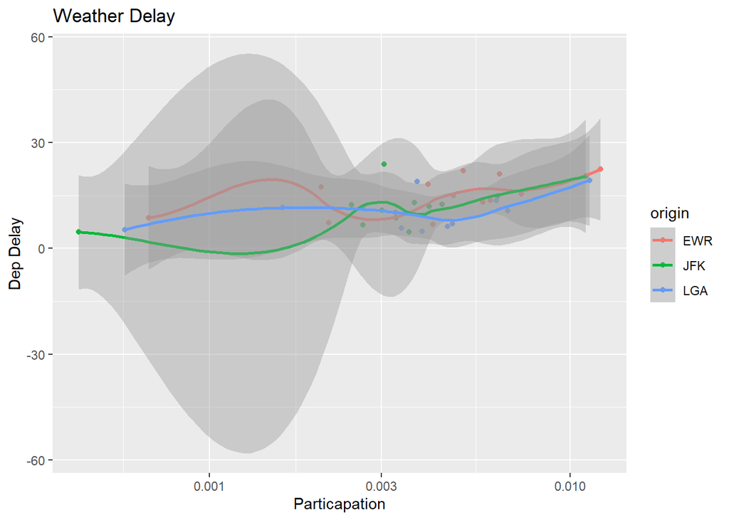

```r
p <- ggplot(weather_delay, aes(x=precip, y=dep_delay, color=origin))+
  geom_point()+ scale_x_log10()+
  labs(x="Particapation", y="Dep Delay", title="Weather Delay")+
  geom_smooth()
p
```

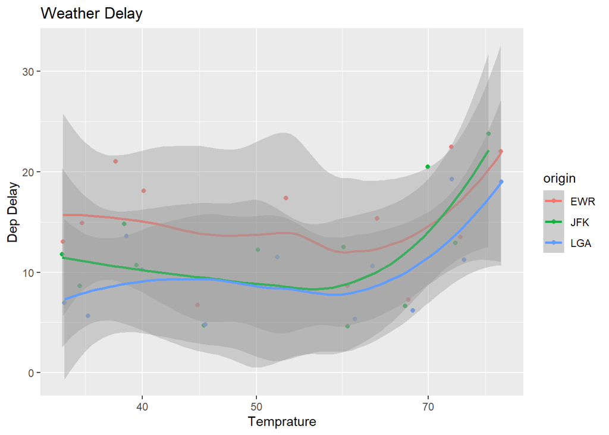

```r
# Plot the delay against the temperature of the day
t <- ggplot(weather_delay, aes(x=temp, y=dep_delay, color=origin))+
  geom_point()+ scale_x_log10()+
  labs(x="Temprature", y="Dep Delay", title="Weather Delay")+
  geom_smooth()
t
```

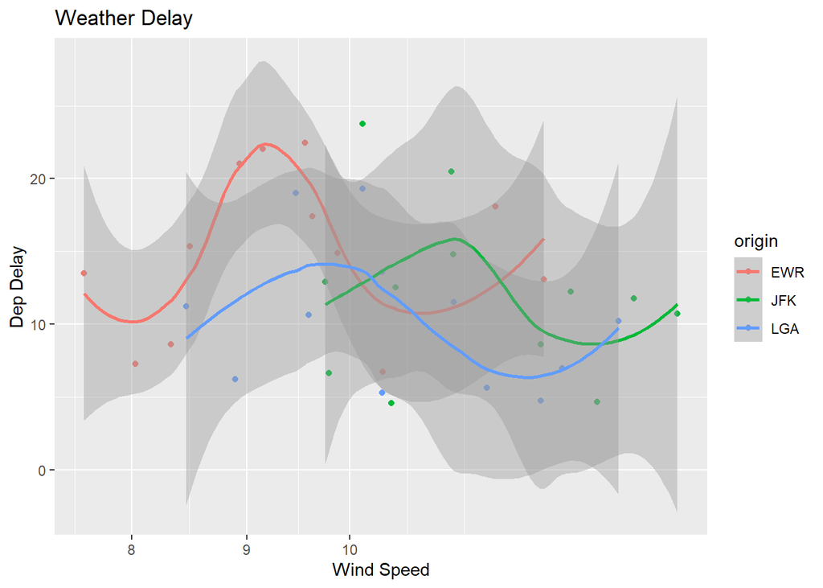

```r
# Plot the delay against the wind speed of the day
w <- ggplot(weather_delay, aes(x=wind_speed, y=dep_delay, color=origin))+
  geom_point()+ scale_x_log10()+
  labs(x="Wind Speed", y="Dep Delay", title="Weather Delay")+
  geom_smooth()
w
```

Can you spot any correlations?

Now try to represent several variables in the dataset at once in the same plot. In particular, represent in a single scatterplot the `wind_speed`, the `temp`, the `precip` and the `dep_delay`. Remember that you can use several different aesthetic channels at the same time, one for each different variable. Examples of the aesthetics you might want to use are `x`, `y`, `size`, `color`, `shape`.

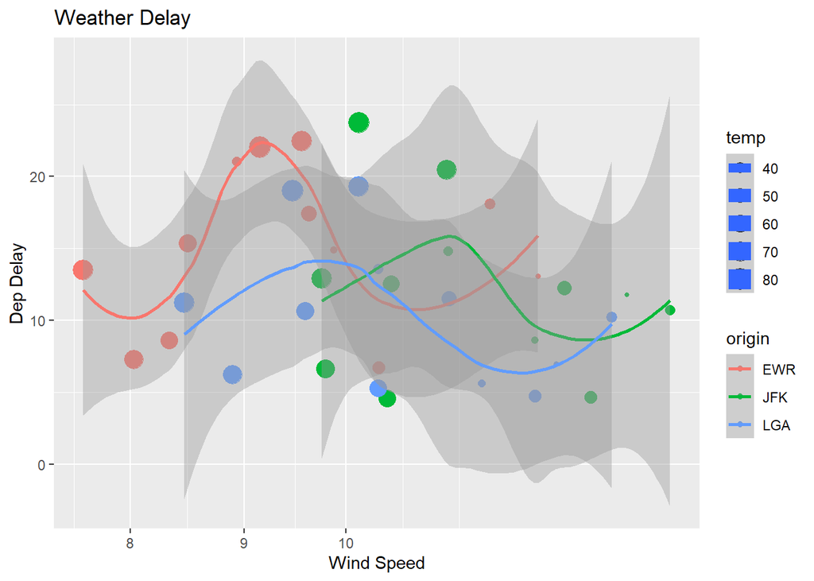

```r
# Your solution here
sol <- ggplot(weather_delay, aes(x=wind_speed, y=dep_delay, color=origin, size=temp))+
  geom_point()+ scale_x_log10()+
  labs(x="Wind Speed", y="Dep Delay", title="Weather Delay")+
  geom_smooth()
sol
```

## Is there a dependency on the time of the year?

Consider the `flights` dataset.

- Plot the departure delay against the month. Can you discern any pattern from the plot?

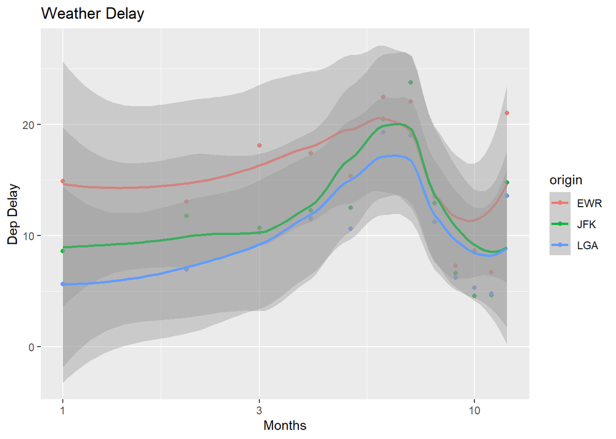

```r
# your solution here
mon <- ggplot(weather_delay, aes(x=month, y=dep_delay, color=origin))+
  geom_point()+ scale_x_log10()+
  labs(x="Months", y="Dep Delay", title="Weather Delay")+
  geom_smooth()
mon
```

- Try to plot the *average* delay against the month. What can you conclude? *Hint*: you can either compute the average delay in the preprocessing pipeline using `group_by` and  
  `summarise` or you can use the `stat = "summary"` argument to `geom_point` or `geom_bar`.

```r
# your solution here
weather_delay%>%
group_by(month) %>%
  summarise(dep_delay = mean(dep_delay, na.rm=TRUE))
```

```
## # A tibble: 12 x 2
##    month dep_delay
##    <int>     <dbl>
##  1     1      9.72
##  2     2     10.6
##  3     3     13.0
##  4     4     13.7
##  5     5     12.8
##  6     6     20.8
##  7     7     21.6
##  8     8     12.6
##  9     9      6.71
## 10    10      6.18
## 11    11      5.39
## 12    12     16.5
```

```
## No summary function supplied, defaulting to `mean_se()`
```

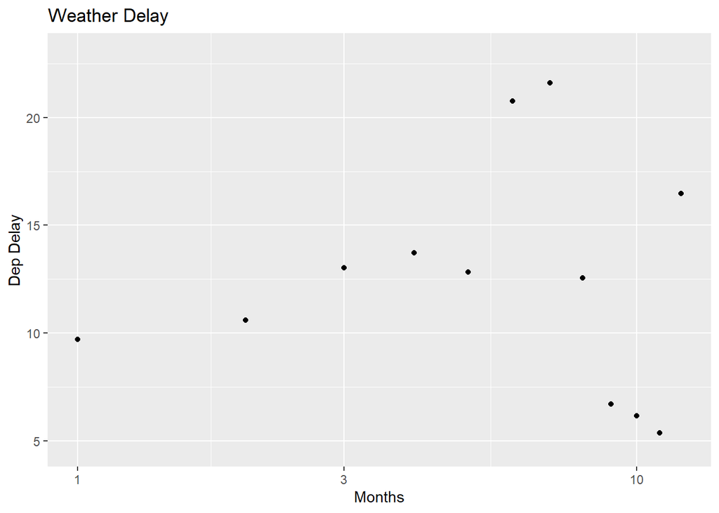

```r
av <- ggplot(weather_delay, aes(x=month, y=dep_delay, group=month))+
  geom_point(stat = "summary")+ scale_x_log10()+
    labs(x="Months", y="Dep Delay", title="Weather Delay")+
    geom_smooth()

av
```

- What about plotting the delay against the day of the year (thus ranging from 1 to 365)? You can use the `days` dataframe provided below to get the day of the year. Remember that there are several flights per day, so you will have to take the average delay for each day of the year.

```r
days <- flights %>%
  distinct(month, day)%>%
  arrange(month, day) %>%
  mutate(day_of_year = row_number())
days
```

```
## # A tibble: 365 x 3
##    month   day day_of_year
##    <int> <int>       <int>
##  1     1     1           1
##  2     1     2           2
##  3     1     3           3
##  4     1     4           4
##  5     1     5           5
##  6     1     6           6
##  7     1     7           7
##  8     1     8           8
##  9     1     9           9
## 10     1    10          10
## # ... with 355 more rows
```

```
## No summary function supplied, defaulting to `mean_se()`
```

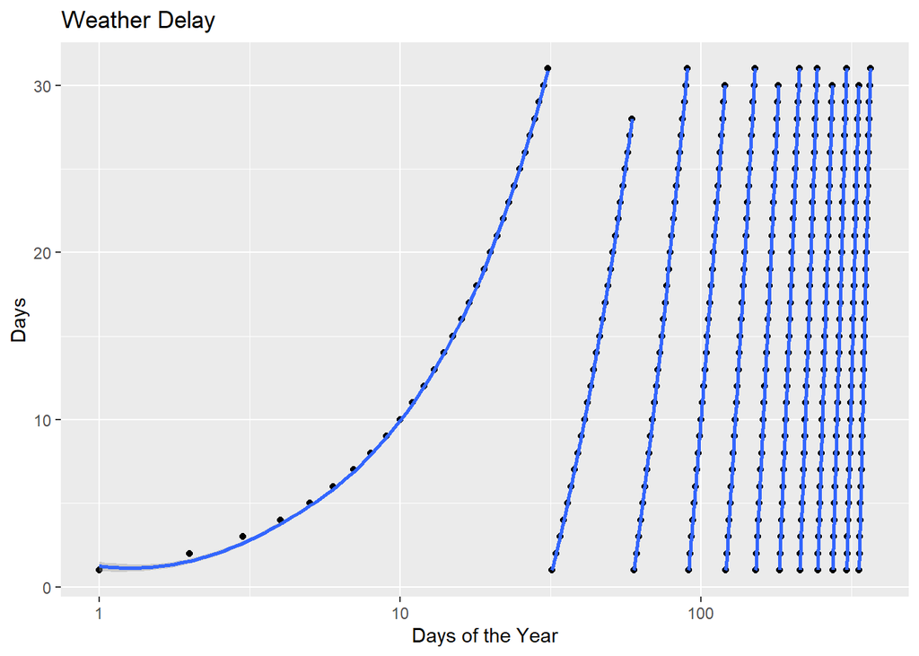

```r
# your solution here

ad <- ggplot(days, aes(x=day_of_year, y=day, group=month))+
  geom_point(stat = "summary")+ scale_x_log10()+
    labs(x="Days of the Year", y="Days", title="Weather Delay")+
    geom_smooth()

ad
```